# Exam 2007 problem 8

### 02409 Multivariate Statistics

`Week J`

Data are $n = 15$ observations of (logarithmes of) leafbrun time and three measure variables of tobacco leaves.

| Variable | Description |
| --- | --- |
| Y | logarithm of leafburn time in seconds |
| X1 | percentage of nitrogen (N) |
| X2 | percentage of chlorine (Cl) |
| X3 | percentage of potassium (K) |

## Question 8.1.

$\sum_{i=1}^{15} (Y_i - \bar{Y})^2$ equals:

1. $2.59$
2. $0.41$
3. $3.0$
4. $0.86$
5. $0.04$
6. $\text{Don't know.}$

## Question 8.2.

The coefficient for X3 (percentage of potassium, K) is significant

1. $\text{at level 0.1 but not at level 0.05}$
2. $\text{at level 0.05 but not at level 0.01}$
3. $\text{at level 0.01 but not at level 0.005}$
4. $\text{at level 0.005 but not at level 0.001}$
5. $\text{at level 0.001 but not at level 0.0005}$
6. $\text{Don't know.}$

## Question 8.3.

The observation most influential on the coefficient for X1 (percentage of nitrogen, N) is observation number:

1. $1$
2. $15$
3. $3$
4. $7$
5. $5$
6. $\text{Don't know.}$

## Question 8.4.

The usual test statistic for the hypothesis that the coefficients for all three independent variables (X1, X2, X3) equal 0 simultaneously has the value:

1. $22.90$
2. $0.8620$
3. $-6.22 - 4.86 + 3.97$
4. $(-6.22)^2 + (-4.86)^2 + (3.97)^2$
5. $29.97$
6. $\text{Don't know.}$

## Question 8.5.

For a new observation the expected value is estimated at 0.7. The variance of the estimate is estimated at 0.01. A 95%-confidence interval for the expected value is then:

1. $[0.7 - 2.201 \cdot 0.01 ; 0.7 + 2.201 \cdot 0.01]$
2. $[0.7 - 2.201 \cdot 0.1 ; 0.7 + 2.201 \cdot 0.1]$
3. $[0.7 - 1.796 \cdot 0.01 ; 0.7 + 1.796 \cdot 0.01]$
4. $[0.7 - 1.796 \cdot 0.1 ; 0.7 + 1.796 \cdot 0.1]$
5. $[0.7 - 2.201 \cdot \sqrt{0.1+1} ; 0.7 + 2.201 \cdot \sqrt{0.1+1}]$
6. $\text{Don't know.}$

## Question 8.6.

Below the residuals from the regression analysis are plotted against: the predicted value (top left plot) and 5 other variables (Z1,Z2,Z3,Z4,Z5) not previously used in the analysis.

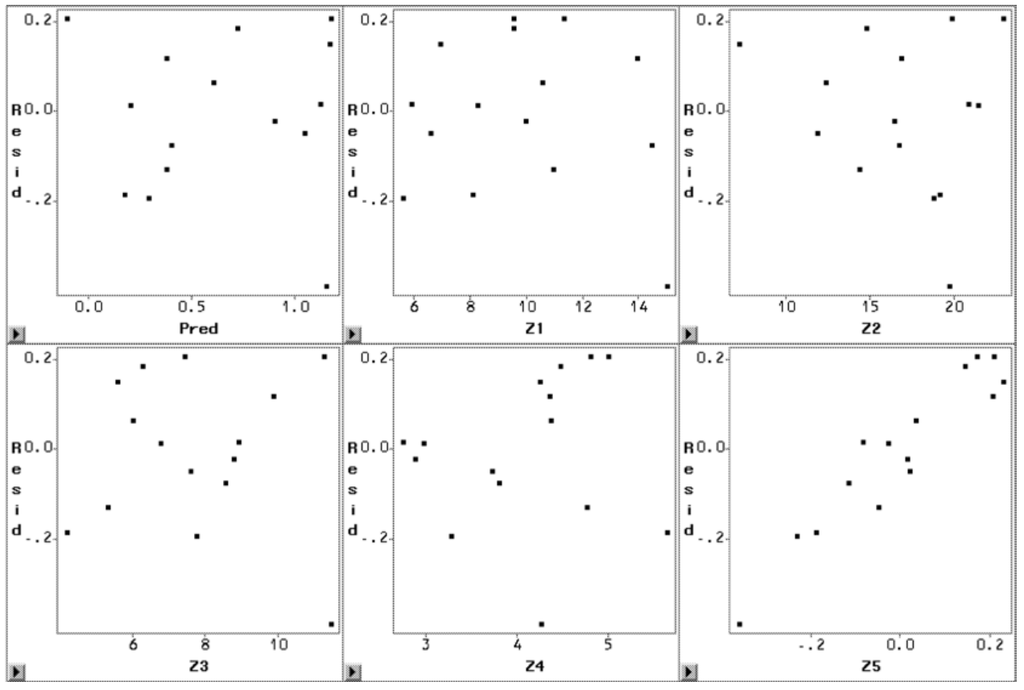

Which single variable should one consider to enter into the analysis?

1. $\text{Z1}$
2. $\text{Z2}$
3. $\text{Z3}$
4. $\text{Z4}$
5. $\text{Z5}$
6. $\text{Don't know.}$